# STT3850 Comprehensive Final Exam

Data Analyses for Questions // Jill E. Thomley

Thursday, December 05, 2019 @ 12:25 AM

## Popularity of Programming Languages

### The Dataset

How can we tell what programming languages are currently most widely used, as well as which languages seem to be growing in popularity or fading over time? One source of data is the programming question-and-answer site Stack Overflow. Each question has a tag or tags that describe its topic(s) and are searchable by users. For example, there is a tag for languages like `R` or Python, as well as for packages like `ggplot2` or `pandas`. By analyzing data on the number of questions tagged for a language, we can get some sense of how many people might be using it. Individuals can access data about Stack Overflow from the Stack Exchange Data Explorer. The rows of the dataset contain frequency counts for individual question tags by year across several years (2008–2018), as well as the total count of all tags for the given year.

[figure not shown]

A Look at the Data

```
# A tibble: 40,518 x 4
    year tag           number year_total
   <dbl> <chr>          <dbl>      <dbl>
 1  2008 .htaccess         54      58390
 2  2008 .net            5910      58390
 3  2008 .net-2.0         289      58390
 4  2008 .net-3.5         319      58390
 5  2008 .net-4.0           6      58390
 6  2008 .net-assembly      3      58390
 7  2008 .net-core          1      58390
 8  2008 2d                42      58390
 9  2008 32-bit            19      58390
10  2008 32bit-64bit        4      58390
# … with 40,508 more rows
```

### Most Common Question Tags

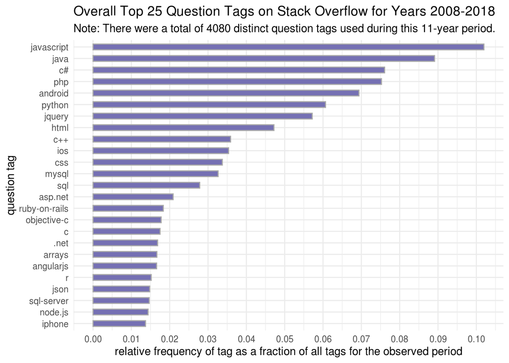

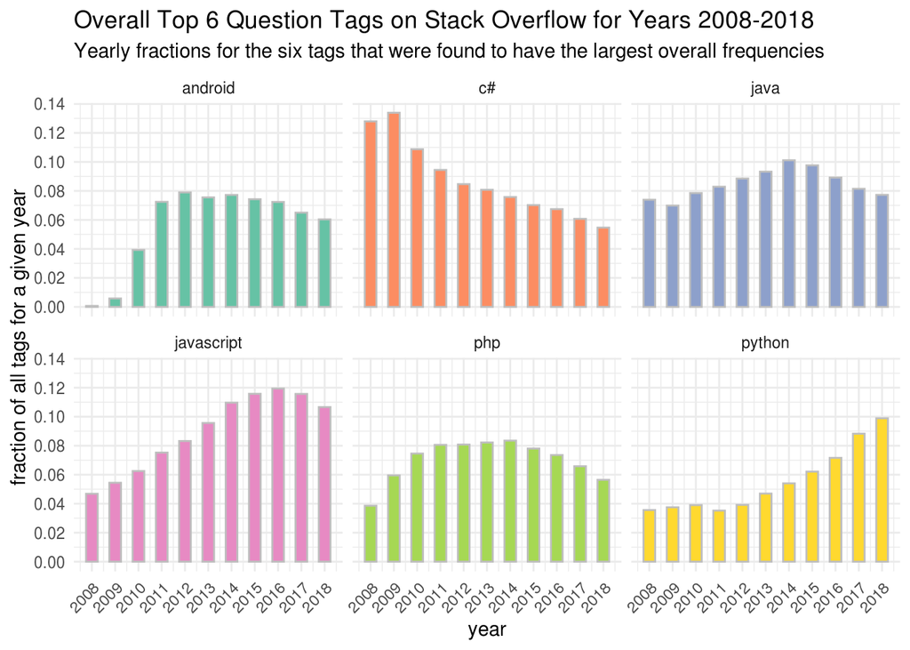

### Tags for `R`, `dplyr`, and `ggplot2`

How has the occurrance of the `R` tag and the two most common `tidyverse` packages changed over time? Can we model this increase using regression analysis?

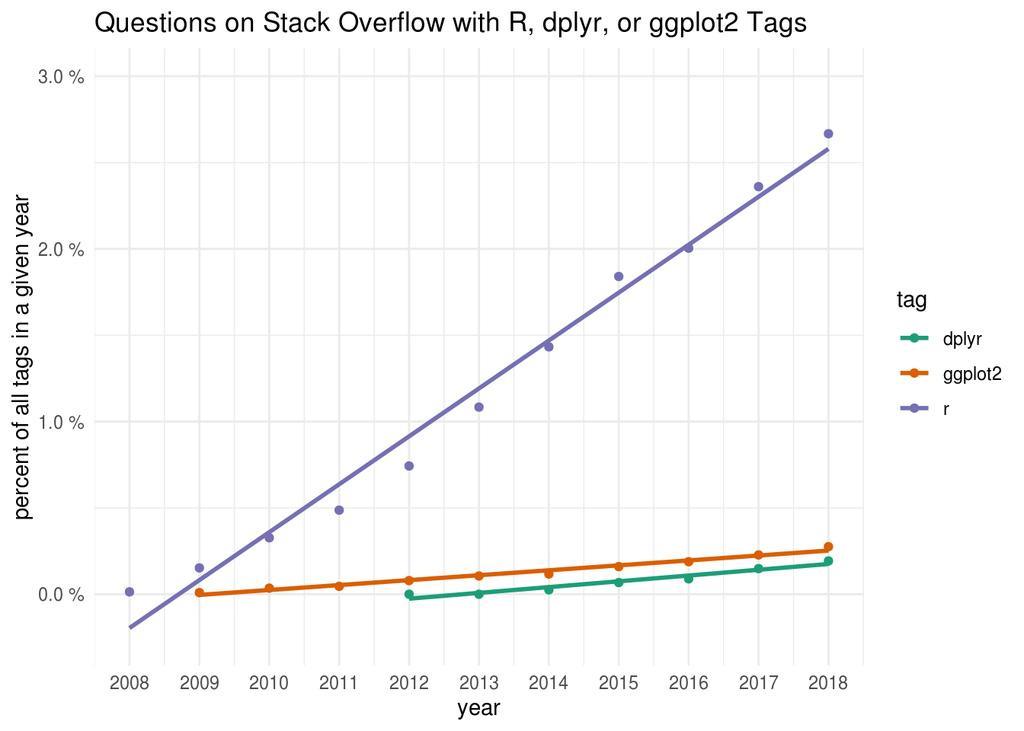

Linear Regression Model for `R` Tag Only

```
Call:
lm(formula = percent ~ year, data = by_tag_year_r)

Residuals:
     Min       1Q   Median       3Q      Max
-0.17161 -0.07247 -0.02033  0.07894  0.20937

Coefficients:
              Estimate Std. Error t value Pr(>|t|)
(Intercept) -557.42216   23.51162  -23.71 2.02e-09 ***
year           0.27750    0.01168   23.76 1.98e-09 ***
---
Signif. codes:  0 '***' 0.001 '**' 0.01 '*' 0.05 '.' 0.1 ' ' 1

Residual standard error: 0.1225 on 9 degrees of freedom
Multiple R-squared:  0.9843,    Adjusted R-squared:  0.9826
F-statistic: 564.5 on 1 and 9 DF,  p-value: 1.978e-09
```

Predictions for Years 2020 and 2030

| ID | year | percent_hat |
| --- | --- | --- |
| 1 | 2020 | 3.134 |
| 2 | 2030 | 5.909 |

## The Importance of Good Handwashing

### The Datasets

Postpartum infections, known puerperal fever or “childbed fever,” are caused by bacteria invading the female reproductive tract following childbirth or miscarriage. Historically it has been a major cause of maternal mortality and it still impacts poorer regions. Hungarian physician Dr. Ignaz Semmelweis (1818–1965), a physician at Vienna General Hospital, pioneered antiseptic procedures to try to prevent such infections. He theorized that the cause was contaminated hands among doctors delivering the babies. The concept of germs were not known at the time, and so routine handwashing before procedures was uncommon. We will analyze Semmelweis’s data to help confirm or refute his theory. One dataset has information about women giving birth in two different clinics at Vienna General Hospital for the years 1841 to 1846. It includes total number of births for the year, as well as the total maternal deaths. The second dataset contains similar data by month from before and after Semmelweis instituted an antiseptic handwashing protocol at Clinic 1 near the end of May 1847—common sense now, but radical at the time! The mortality rate in each time interval is the number of maternal deaths per 100 births.

```
Observations: 12
Variables: 5
$ year           <dbl> 1841, 1842, 1843, 1844, 1845, 1846, 1841, 1842, 1843, …
$ births         <dbl> 3036, 3287, 3060, 3157, 3492, 4010, 2442, 2659, 2739, …
$ deaths         <dbl> 237, 518, 274, 260, 241, 459, 86, 202, 164, 68, 66, 105
$ clinic         <chr> "clinic 1", "clinic 1", "clinic 1", "clinic 1", "clini…
$ mortality_rate <dbl> 7.806324, 15.759051, 8.954248, 8.235667, 6.901489, 11.…
```

```r
# CODE CHUNK #1

handwashing_start = as.Date("1847-06-01")

monthly_deaths <- read_csv("monthly_deaths.csv") %>%
  mutate(mortality_rate = 100 * deaths / births,
         handwashing = ifelse(date < handwashing_start, "dirty", "washed"))
glimpse(monthly_deaths)
```

```
Observations: 98
Variables: 5
$ date           <date> 1841-01-01, 1841-02-01, 1841-03-01, 1841-04-01, 1841-…
$ births         <dbl> 254, 239, 277, 255, 255, 200, 190, 222, 213, 236, 235,…
$ deaths         <dbl> 37, 18, 12, 4, 2, 10, 16, 3, 4, 26, 53, 64, 38, 27, 26…
$ mortality_rate <dbl> 14.5669291, 7.5313808, 4.3321300, 1.5686275, 0.7843137…
$ handwashing    <chr> "dirty", "dirty", "dirty", "dirty", "dirty", "dirty", …
```

### Identifying the Problem

Vienna General Hospital served a large volume of pregnant women in the early 1800s, so they added a second maternity clinic in 1833. By May 1841, the original Clinic 1 was served by doctors and medical students, while midwives and their students served at Clinic 2. Midwives only tended to birthing women, but medical students also spent time in the autopsy rooms examining cadavers. The germ theory of disease had not yet been developed, so no one thought to wash their hands when going from the morgue to the delivery room. Yikes! Semmelweis thought medical students were transferring some kind of “morbid poison” from dissected cadavers to the maternity patients.

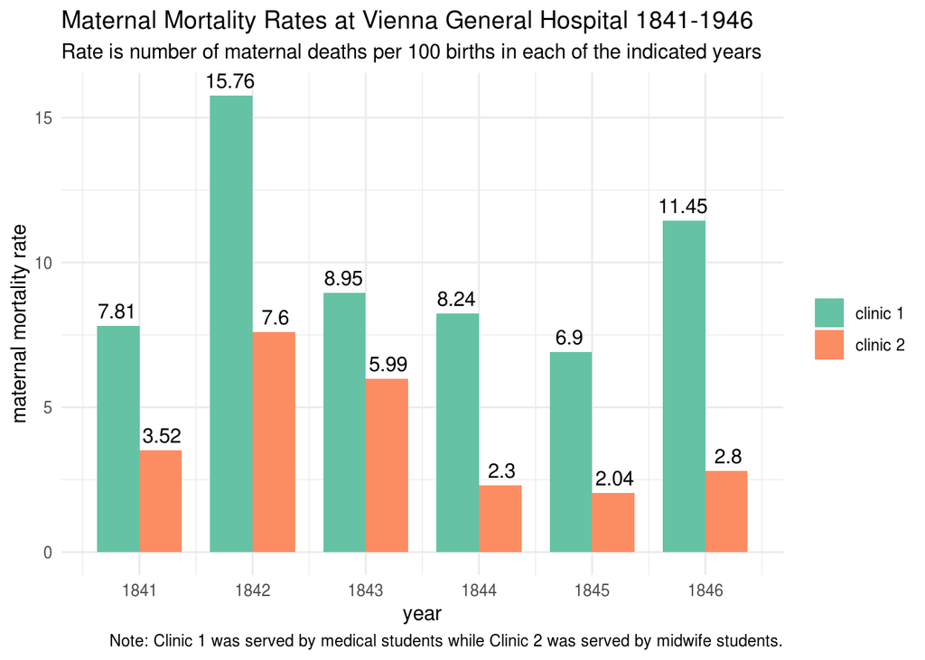

```
# A tibble: 2 x 4
  clinic    xbar  stdv     n
  <chr>    <dbl> <dbl> <int>
1 clinic 1  9.85  3.28     6
2 clinic 2  4.04  2.25     6
```

### Semmelweis’s Intervention

Semmelweis introduced a handwashing protocol using chlorinated lime, which is now known to be a disinfectant. The descriptive analyses below compare maternal mortality rates in Clinic 1 before and after his protocol was introduced.

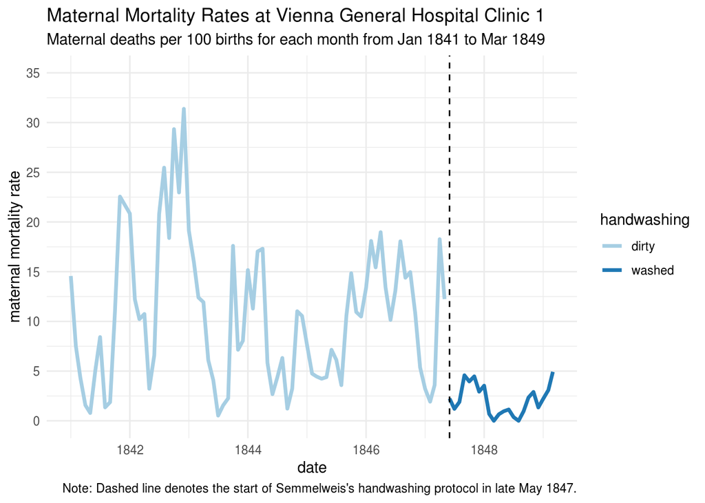

```
# A tibble: 2 x 6
  handwashing  xbar  stdv     n lower_fence upper_fence
  <chr>       <dbl> <dbl> <int>       <dbl>       <dbl>
1 dirty       10.5   7.07    76      -11.6        31.0
2 washed       2.11  1.52    22       -2.17        6.22
```

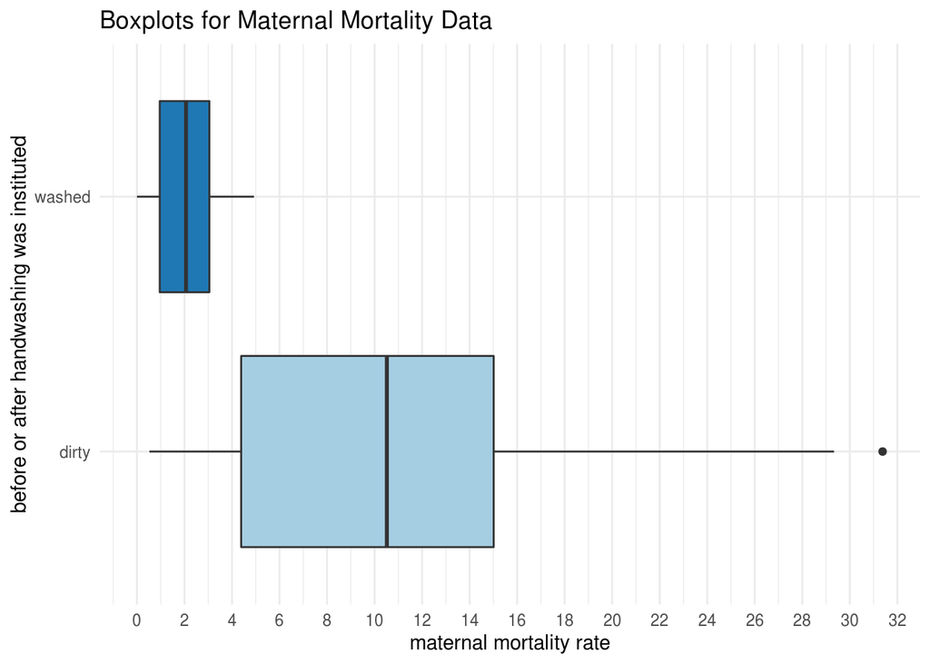

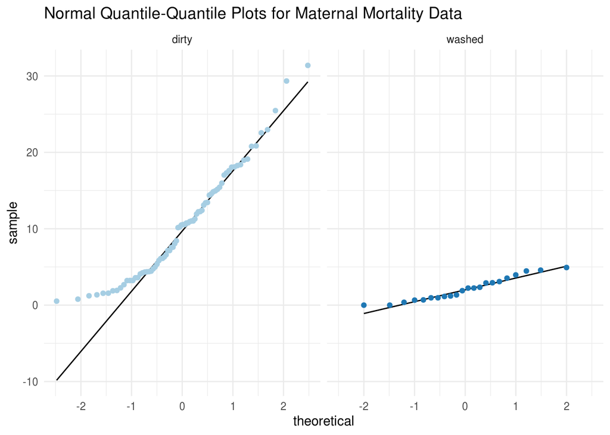

### Does Handwashing Reduce Mortality?

The goal of handwashing was to reduce maternal mortality. On average, were the rates of maternal mortality significantly lower after the handwashing protocol was introduced? The permutation test below seeks to answer that question. The 95% bootstrap percentile is also provided to estimate the difference in mean rates.

```r
# CODE CHUNK #2

teststat <- summaries$xbar[1] - summaries$xbar[2]

testdata <- monthly_deaths %>% pull(mortality_rate)
total_n  <- length(testdata)
group_n  <- summaries$n[1]

sims     <- 10^5-1
randstat <- numeric(sims)

for (i in 1:sims) {
  index       <- sample(total_n, group_n)
  randstat[i] <- mean(testdata[index]) - mean(testdata[-index])
}
```

```
            quantity    value
1     test statistic 8.395661
2 lower-tail p-value 1.000000
3 upper-tail p-value 0.000010
4  two-sided p-value 0.000020
```

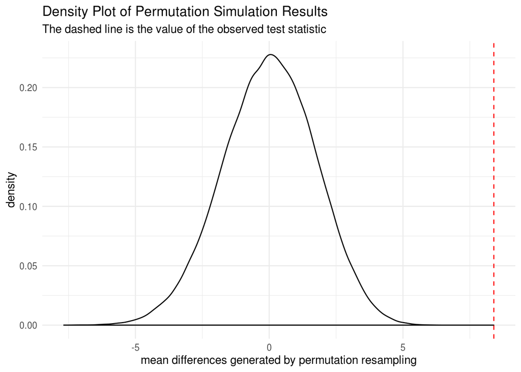

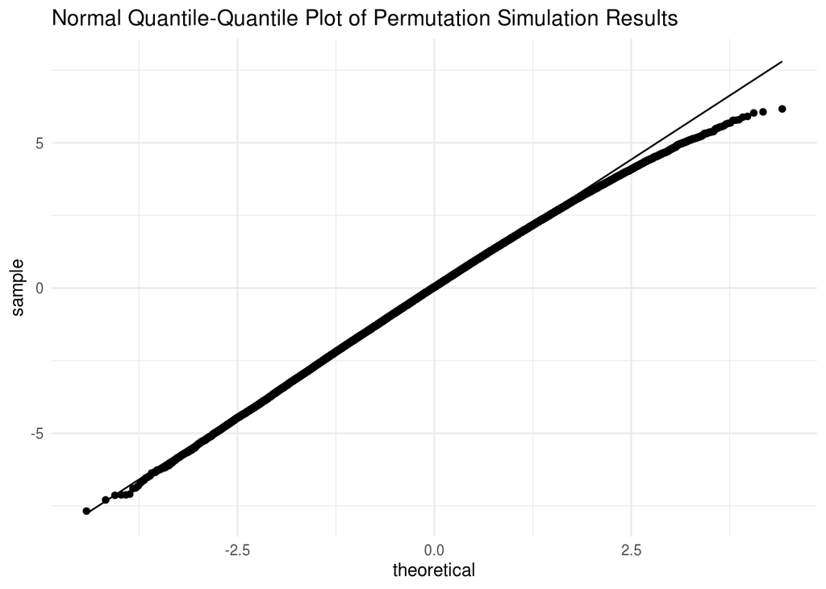

```
                 data   skewness kurtosis
1 permutation results -0.1223502 2.925324
```

```r
# CODE CHUNK #3

data_dirty <- monthly_deaths %>% filter(handwashing == "dirty") %>% pull(mortality_rate)
n_dirty    <- length(data_dirty)

data_clean <- monthly_deaths %>% filter(handwashing == "washed") %>% pull(mortality_rate)
n_clean    <- length(data_clean)

sims       <- 10^5
mean_diffs <- numeric(sims)

for (i in 1:sims) {
    sample_dirty <- sample(data_dirty, n_dirty, replace = TRUE)
    sample_clean <- sample(data_clean, n_clean, replace = TRUE)
    mean_diffs[i] <- mean(sample_dirty) - mean(sample_clean)
}

round(quantile(mean_diffs, c(.025, .975)), 2)
```

```
 2.5% 97.5%
 6.73 10.12
```

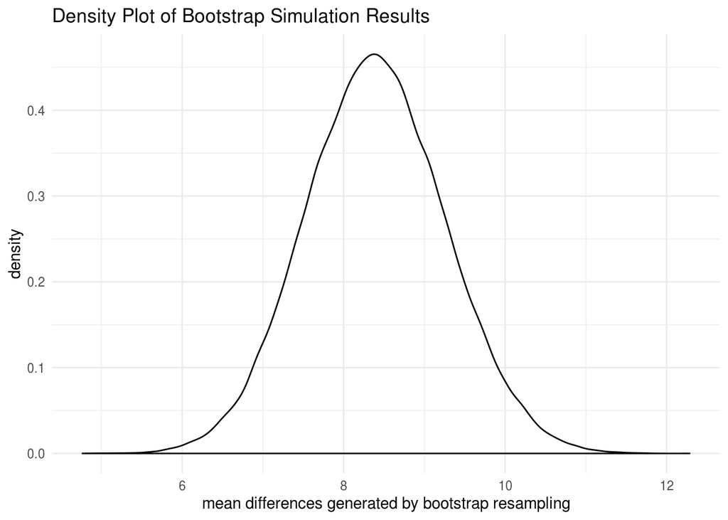

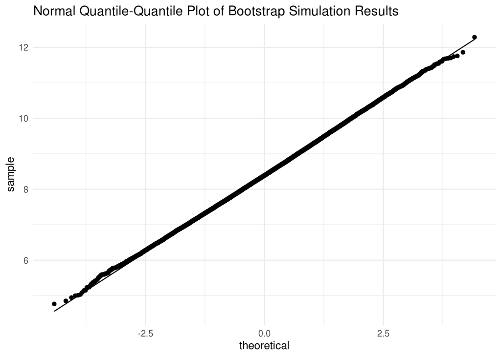

```
               data   skewness kurtosis
1 bootstrap results 0.05486677  2.98408
```